# Homework 5

Kim Ayers

# 1 Problem 1 - KNN with Wine Data Set

In the `wine_quality_red` dataset we have several predictors that we want to use to predict the quality of wines where the quality measurement was given by an expert wine taster.

## 1.1 Part a

Start by breaking the quality measurements into two bins: low quality and high quality. Do so in a way where there are roughly the same number of high quality wines as low quality wines. A table of the counts for each quality measurements is shown below.

```r
wine<-read.csv("winequality-red.csv")
table(wine$quality)
```

```
##
##   3   4   5   6   7   8
##  10  53 681 638 199  18
```

```r
wine<- wine%>%
  mutate(lowhigh=ifelse(quality>=6,"high","low"))

for (i in 1:11){
 wine[,i]<-scale(wine[,i])
}
```

## 1.2 Part b

Use cross validation to build a KNN model to predict the quality of the wine. Write code to make a plot of the test error rate against $1/K$ and use this plot to choose the best value of $K$. Report your cross validation classification training error, the number of neighbors that you use to build this model, and which predictors that you used to build your model.

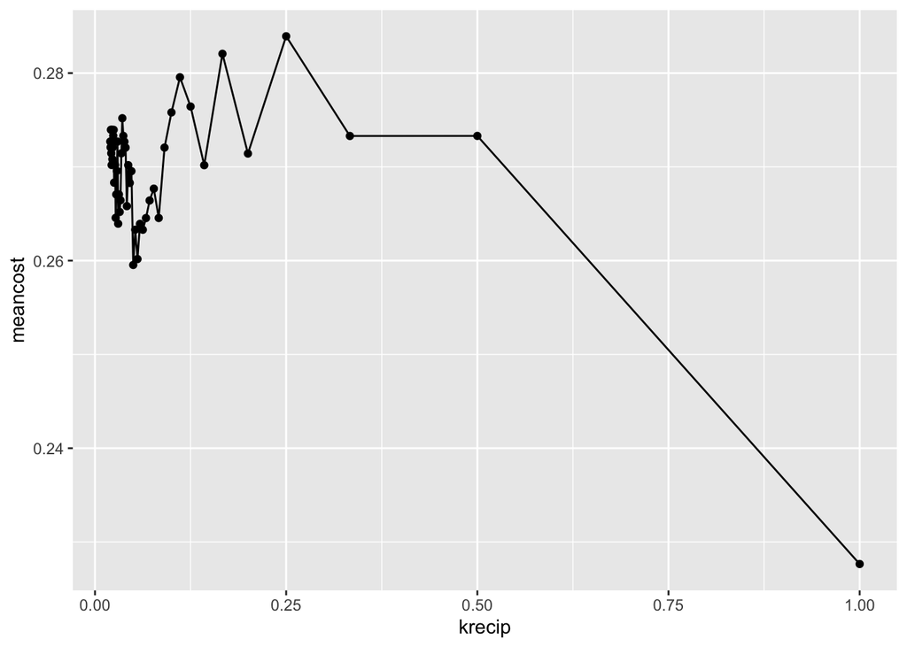

```r
minneigh<-1
numneigh<-50
kcosts<-data.frame(k=seq(minneigh,numneigh),
                   meancost=rep(0,numneigh-minneigh+1))

folds<-createFolds(1:nrow(wine),k=10,returnTrain=TRUE)
costs<-rep(0,10)
for (neigh in minneigh:numneigh){
  for (j in 1:10){
    winefold<-wine[folds[[j]],]
    knn_model<-knn(
      train=winefold%>%
        select(-quality,-lowhigh),
      test=wine[-folds[[j]],]%>%
        select(-quality,-lowhigh),
      cl=winefold$lowhigh,
      k=neigh
    )
    testing<-wine[-folds[[j]],]%>%
      mutate(QualityTest=knn_model)%>%
      mutate(Correct=ifelse(QualityTest==lowhigh,0,1))

#    for (i in 1:nrow(testing)){
 #     if (testing$SpeciesTest[i]==Testing$Species[i]){
  #      testing$Correct[i]<-0
  #    }
   #   else {
    #    testing$Correct[i]<-1
    #  }


    costs[j]<-mean(testing$Correct)
  }
  kcosts$meancost[neigh-minneigh+1]<-mean(costs)
}

kcosts<-kcosts%>%
  mutate(krecip=1/k)

#ggplot(data=kcosts,aes(x=k,y=meancost))+
#  geom_line()+geom_point()+
#  scale_x_reverse()

ggplot(data=kcosts,aes(x=krecip,y=meancost))+
  geom_line()+geom_point()
```

```r
kcostsarr<-kcosts%>%
  arrange(meancost)
```

## 1.3 Part c

Now perform PCA on the wine data predictors. Use the singular values to reduce the dimension of the problem and build a KNN model on the reduced data. Use cross validation to estimate the classification testing error of your model. Write code to make a plot of the test error rate against $1/K$ and use this plot to choose the best value of $K$. Report the estimated error, the number of neighbors, and the dimension that you use to build your model.

```r
X<-as.matrix(wine[,1:11])

for (j in 1:11){
  X[,j]<-X[,j]-mean(X[,j])
}

svdX<-svd(X)

explained_variance<-svdX$d/sum(svdX$d)

cumsum(explained_variance)
```

```
##  [1] 0.1767890 0.3161538 0.4412019 0.5518151 0.6501733 0.7317335 0.8084632
##  [8] 0.8737737 0.9327285 0.9754921 1.0000000
```

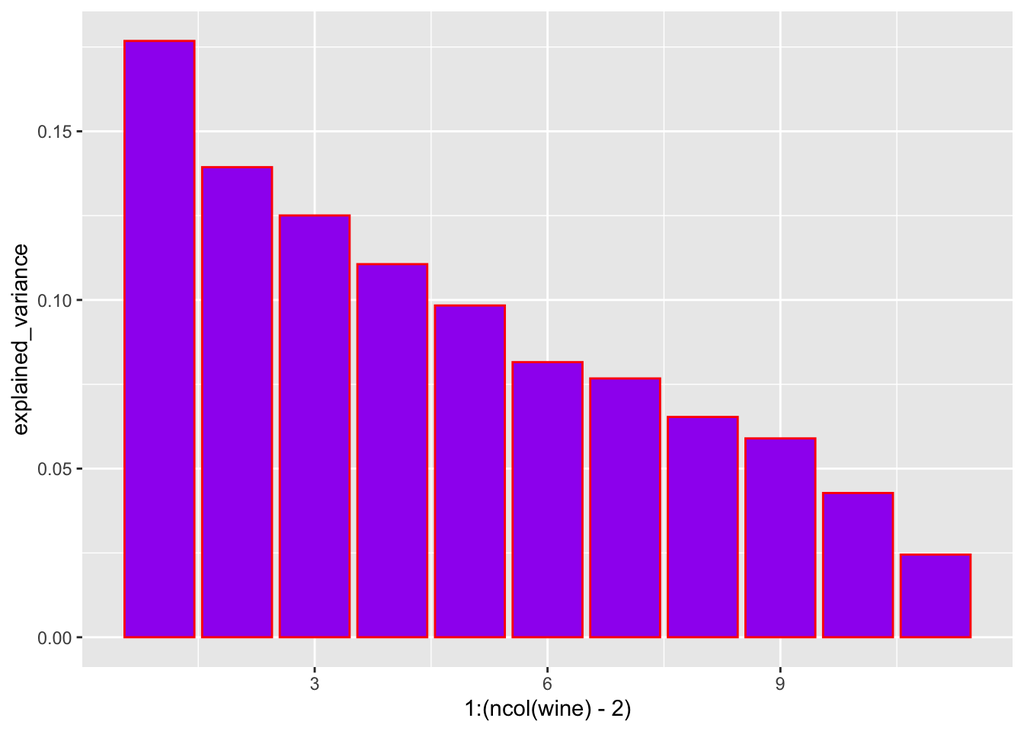

```r
ggplot()+
  geom_col(aes(x=1:(ncol(wine)-2),y=explained_variance),fill="purple",color="red")
```

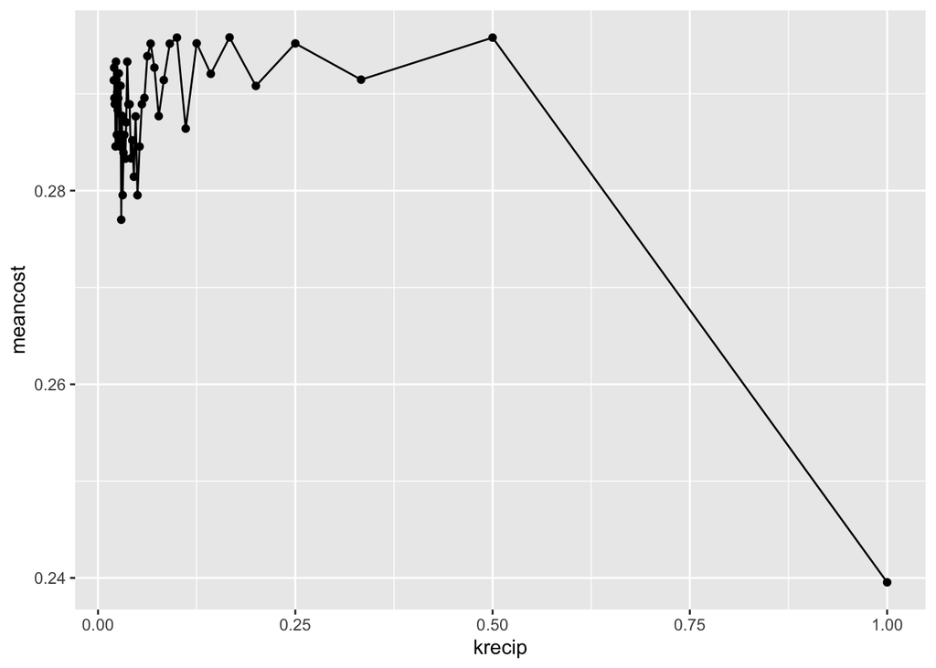

```r
p=4
 U<-svdX$u[,1:p]
numneigh<-50
kcosts<-data.frame(k=seq(1,numneigh),
                   meancost=rep(0,numneigh))


for (neigh in 1:numneigh){
  folds<-createFolds(1:nrow(wine),k=10,returnTrain=TRUE)
  costs<-rep(0,10)
  for (j in 1:10){
    winefold<-wine[folds[[j]],]
    knn_model<-knn(
      train=U[folds[[j]],],
      test=U[-folds[[j]],],
      cl=winefold$lowhigh,
      k=neigh
    )
    testing<-wine[-folds[[j]],]%>%
      mutate(QualityTest=knn_model)%>%
      mutate(Correct=ifelse(QualityTest==lowhigh,0,1))

    #    for (i in 1:nrow(testing)){
    #     if (testing$SpeciesTest[i]==Testing$Species[i]){
    #      testing$Correct[i]<-0
    #    }
    #   else {
    #    testing$Correct[i]<-1
    #  }


    costs[j]<-1/nrow(testing)*sum(testing$Correct)
  }
  kcosts$meancost[neigh]<-mean(costs)
}

kcosts<-kcosts%>%
  mutate(krecip=1/k)

ggplot(data=kcosts,aes(x=krecip,y=meancost))+
  geom_line()+geom_point()
```

```r
kcostsarr<-kcosts%>%
  arrange(meancost)
```